# Identification of common variables

Mathijn Wilkens

08 March, 2018

The aim of this step is to assess the variables X that are common to both datasets. Excel annex shows the first assessment on the basis of the questionnaires and here the similarty of the distributions of those variables will be checked. In some cases, recodes may be required. Also, this step removes the inactive respondents from the EQLS sample.

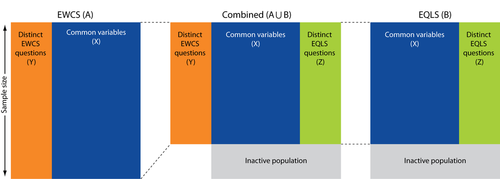

# Preparation

```r
library(StatMatch)
library(survey)
library(ggplot2)
library(reshape2)
library(car)
library(knitr)
library(ggcorrplot)
```

```r
source("Colours.R")
```

Datafiles created in ‘import_data.R’

```r
load("EWCS_raw.Rda")
load("EQLS_raw.Rda")
```

# Harmonise population

Select working population based on EQLS definition.

```r
EQLS <- subset(EQLS_raw, employed==1)
EWCS <- subset(EWCS_raw, (y15_Q2c=="at work as employee or employer/self-employed* / relative assisting on family farm or business** " |
                         y15_Q2c=="at work and on child-care leave or other leave                                                   " |
                         y15_Q2c=="retired                                                                                          " ) &
                         y15_Q2b!="15" & y15_Q2b!="16" & y15_Q2b!="17")

#correcting one empty degurba
EQLS$Y16_Degurba[is.na(EQLS$Y16_Degurba)] <- "Large town"
```

This drops 15290 cases in the EQLS because they are not employed. This also drops 1488 cases in the EWCS. We will have to assume the weighting still applies. The mean of the weight is now 0.9948395 so that seems reasonable.

It is important to consider that the weight no longer averages to 1 because the original weighting applies to the full sample and because the definition of the population has changed, so has the weight. For EQLS that shouldn’t matter, because employement status was a poststratification variable. Neverthless there is a difference, which may be due to trimming of weights.

Making sure country and urbanisation have the same labels and levels

```r
EWCS$country[EWCS$countid=="Austria"] <- 1
EWCS$country[EWCS$countid=="Belgium"] <- 2
EWCS$country[EWCS$countid=="Bulgaria"] <- 3
EWCS$country[EWCS$countid=="Croatia"] <- 4
EWCS$country[EWCS$countid=="Cyprus"] <- 5
EWCS$country[EWCS$countid=="Czech Republic"] <- 6
EWCS$country[EWCS$countid=="Denmark"] <- 7
EWCS$country[EWCS$countid=="Estonia"] <- 8
EWCS$country[EWCS$countid=="Finland"] <- 9
EWCS$country[EWCS$countid=="France"] <- 10
EWCS$country[EWCS$countid=="Germany"] <- 11
EWCS$country[EWCS$countid=="Greece"] <- 12
EWCS$country[EWCS$countid=="Hungary"] <- 13
EWCS$country[EWCS$countid=="Ireland"] <- 14
EWCS$country[EWCS$countid=="Italy"] <- 15
EWCS$country[EWCS$countid=="Latvia"] <- 16
EWCS$country[EWCS$countid=="Lithuania"] <- 17
EWCS$country[EWCS$countid=="Luxembourg"] <- 18
EWCS$country[EWCS$countid=="Malta"] <- 19
EWCS$country[EWCS$countid=="Netherlands"] <- 20
EWCS$country[EWCS$countid=="Poland"] <- 21
EWCS$country[EWCS$countid=="Portugal"] <- 22
EWCS$country[EWCS$countid=="Romania"] <- 23
EWCS$country[EWCS$countid=="Slovenia"] <- 24
EWCS$country[EWCS$countid=="Slovakia"] <- 25
EWCS$country[EWCS$countid=="Spain"] <- 26
EWCS$country[EWCS$countid=="Sweden"] <- 27
EWCS$country[EWCS$countid=="United Kingdom"] <- 28

EWCS$country <- factor(EWCS$country,levels=c(1:28),
                         labels=c("Austria","Belgium","Bulgaria","Croatia","Cyprus","Czech Republic","Denmark","Estonia","Finland","France","Germany","Greece","Hungary","Ireland","Italy","Latvia","Lithuania","Luxembourg","Malta","Netherlands","Poland","Portugal","Romania","Slovenia","Slovakia","Spain","Sweden","United Kingdom"),
                         ordered=F)


EQLS$country[EQLS$Y16_Country=="Austria"] <- 1
EQLS$country[EQLS$Y16_Country=="Belgium"] <- 2
EQLS$country[EQLS$Y16_Country=="Bulgaria"] <- 3
EQLS$country[EQLS$Y16_Country=="Croatia"] <- 4
EQLS$country[EQLS$Y16_Country=="Cyprus"] <- 5
EQLS$country[EQLS$Y16_Country=="Czech Republic"] <- 6
EQLS$country[EQLS$Y16_Country=="Denmark"] <- 7
EQLS$country[EQLS$Y16_Country=="Estonia"] <- 8
EQLS$country[EQLS$Y16_Country=="Finland"] <- 9
EQLS$country[EQLS$Y16_Country=="France"] <- 10
EQLS$country[EQLS$Y16_Country=="Germany"] <- 11
EQLS$country[EQLS$Y16_Country=="Greece"] <- 12
EQLS$country[EQLS$Y16_Country=="Hungary"] <- 13
EQLS$country[EQLS$Y16_Country=="Ireland"] <- 14
EQLS$country[EQLS$Y16_Country=="Italy"] <- 15
EQLS$country[EQLS$Y16_Country=="Latvia"] <- 16
EQLS$country[EQLS$Y16_Country=="Lithuania"] <- 17
EQLS$country[EQLS$Y16_Country=="Luxembourg"] <- 18
EQLS$country[EQLS$Y16_Country=="Malta"] <- 19
EQLS$country[EQLS$Y16_Country=="Netherlands"] <- 20
EQLS$country[EQLS$Y16_Country=="Poland"] <- 21
EQLS$country[EQLS$Y16_Country=="Portugal"] <- 22
EQLS$country[EQLS$Y16_Country=="Romania"] <- 23
EQLS$country[EQLS$Y16_Country=="Slovenia"] <- 24
EQLS$country[EQLS$Y16_Country=="Slovakia"] <- 25
EQLS$country[EQLS$Y16_Country=="Spain"] <- 26
EQLS$country[EQLS$Y16_Country=="Sweden"] <- 27
EQLS$country[EQLS$Y16_Country=="United Kingdom"] <- 28

EQLS$country <- factor(EQLS$country,levels=c(1:28),
                         labels=c("Austria","Belgium","Bulgaria","Croatia","Cyprus","Czech Republic","Denmark","Estonia","Finland","France","Germany","Greece","Hungary","Ireland","Italy","Latvia","Lithuania","Luxembourg","Malta","Netherlands","Poland","Portugal","Romania","Slovenia","Slovakia","Spain","Sweden","United Kingdom"),
                         ordered=F)


EQLS$urbanisation[EQLS$Y16_Degurba=="Large town"] <- 1
EQLS$urbanisation[EQLS$Y16_Degurba=="50001-200000"] <- 1
EQLS$urbanisation[EQLS$Y16_Degurba=="200001+"] <- 1
EQLS$urbanisation[EQLS$Y16_Degurba=="Small or middle sized town"] <- 2
EQLS$urbanisation[EQLS$Y16_Degurba=="10001 - 50000"] <- 2
EQLS$urbanisation[EQLS$Y16_Degurba=="Rural area or village"] <- 3
EQLS$urbanisation[EQLS$Y16_Degurba=="<=10000"] <- 3

EQLS$urbanisation <- factor(EQLS$urbanisation, levels=c(1:3), labels=c("Densely populated area","Intermediate area","Thinly populated area"),ordered=F)

EWCS$urbanisation[EWCS$EWCS_urbanisation1_3=="Urban"] <- 1
EWCS$urbanisation[EWCS$EWCS_urbanisation1_3=="Intermediate"] <- 2
EWCS$urbanisation[EWCS$EWCS_urbanisation1_3=="Rural"] <- 3

EWCS$urbanisation <- factor(EWCS$urbanisation, levels=c(1:3), labels=c("Densely populated area","Intermediate area","Thinly populated area"),ordered=F)
```

# Harmonise variables

The aim here is to check whether the same variables in the EWCS follow the same distribution in the EQLS. We can do this by

- Eyeballing the distribution
- Calculating Hellinger’s distance, which is a measure of dissimilarity of the distributions. A rule of thumb for Hellingers distance is that we can consider distributions to be equal if the value is below 0.05. Hellingers distance is based on frequency tables which for the purposes of this excersise have been weighted. This is not robust at all, because if sample sizes are smaller, distributions are more likely to diverge as a result of statistical uncertainty. This is evident when looking at Hellingers distance by country.
- Statistical tests between distributions, e.g. a t-test for continuous variables are difficult because we need to take into account the variance due to clustering. One option is to divide the Chi-square test by the generalised design effect of both surveys. The ‘Delta H0’ shows the value of the generalised design effect that would determine the acceptance of the null hypothesis (equality of distributions) in the case of alpha=0.05 (df=J-1). In other words: the minimum design effect we would have to assume in order to conclude the disributions are the same.

My impression is that deciding on whether two variables from two surveys can be considered coherent is largely a subjective choice in the end. Subjective in the sense that there are no conclusive statistical tests. To interpret the Chi square we need to know something about the design effect for each variable. This is difficult to calculate now because we would need to reweigh both datasets to the new definition of the population. Also, if we would have the design effect we are more likely to conclude the distributions are not dissimilar if we have a higher sample size and/or a smaller design effect. I am not sure if that is a sensible way of assessing this. What makes more sense to me is setting a threshold of a certain degree of dissimilarity, i.e. the differences between the distributions within that threshold would be considered acceptable. Of course the level of the threshold itself is also arbitrary, but at least this is a systematic way of looking at it. Eurostat (2013) mentions a threshold of 0.05 for Hellingers distance which I will apply here as well. There are exceptions to this measure: Hellingers distance cannot be calculated for continuous variables and if categories have many variables Hellingers distance becomes less effective.

```r
#Function for svydesign
define_svy <- function(data_EWCS=EWCS,data_EQLS=EQLS) {

  EWCS_svyd <<- svydesign(id=~EWCS_samplepoint, strata=~countid+EWCS_region+EWCS_sizeoflocality, weights=~w5_EU28, data=data_EWCS)
  EQLS_svyd <<- svydesign(~Y16_Samplingpoint,strata=~Y16_Country+Y16_Region+Y16_Degurba,weights=~WCalib_crossnational_EU28,data=data_EQLS)

}

#Function for Hellingers distance
Helld <- function(x,y,data_EWCS=EWCS,data_EQLS=EQLS) {

            define_svy(data_EWCS,data_EQLS)

            comp.prop(
            svytable(x, EQLS_svyd),
            svytable(y, EWCS_svyd),
            sum(svytable(x, EQLS_svyd)),
            sum(svytable(y, EWCS_svyd)))
      }

#Function for plot with Hellingers distance
HD <- function(x,y,name="variable") {

  define_svy()

  h <- Helld(x,y)

  t_EQLS <- prop.table(svytable(x, EQLS_svyd))
  t_EQLS <- melt(t_EQLS)
  t_EQLS$Data <- "EQLS"
  colnames(t_EQLS)[1] <- name
  t_EWCS <- prop.table(svytable(y, EWCS_svyd))
  t_EWCS <- melt(t_EWCS)
  colnames(t_EWCS)[1] <- name
  t_EWCS$Data <- "EWCS"
  df <- rbind(t_EQLS,t_EWCS)

  p <- ggplot(df, aes_string(x=name,y="value",fill="Data"))
 print(p + geom_bar(stat="identity", position="dodge") +
          scale_fill_manual(values=EF_2c2, name=paste("\n\nHellinger's \ndistance:\n\n",
                                                      round(h$meas[4],3),
                                                      "\n\nDelta H0:\n\n",
                                                      round(h$chi.sq[4],3)
                                                      )) +
          guides(fill = guide_legend(title.position = "bottom")) +
          theme_minimal() +
          theme(axis.title.y=element_blank()))
}


#Function for plot with hellingers distance by country
Helld_country <- function(x,y) {

  s <- as.data.frame(
          sapply(
            levels(EWCS$country),
            FUN=function(x,y,z) {EWCS <- subset(EWCS, country==z)
                                 EQLS <- subset(EQLS, country==z)
                                 h <- Helld(x,y,data_EWCS=EWCS,data_EQLS=EQLS)
                                 h$meas[4]},
            x=x,y=y,simplify = F
                )
                    )
  s <- melt(s,value.name="HD",variable.name="Country", id.vars=NULL)

  ggplot(s,aes(x=Country,y=HD)) +
    geom_bar(stat="identity",fill=EF_blue) +
    coord_flip() +
    scale_x_discrete(limits = rev(levels(s$Country))) +
    scale_y_continuous(expand = c(0, 0)) +
    geom_hline(yintercept=0.05) +
    ylab("Hellinger's distance") +
    theme_minimal() +
    theme(panel.grid.major.y = element_blank(),
          axis.title.y = element_blank())
}
```

### Gender

Variable name: Gender

**Conclusion: same distribution**

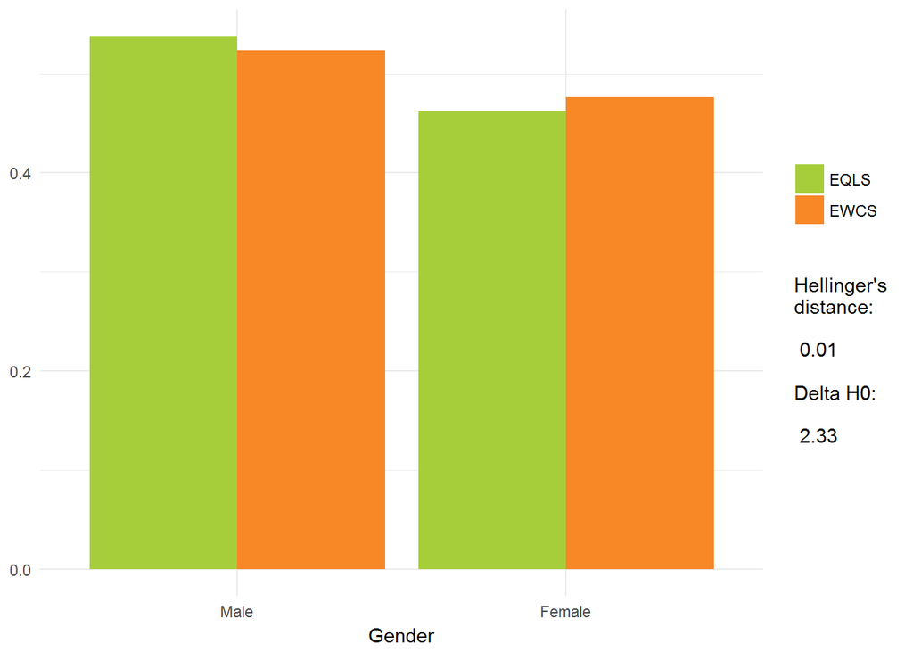

```r
levels(EWCS$y15_Q2a) <- c("Male","Female")

HD(~Y16_HH2a,~y15_Q2a,name="Gender")
```

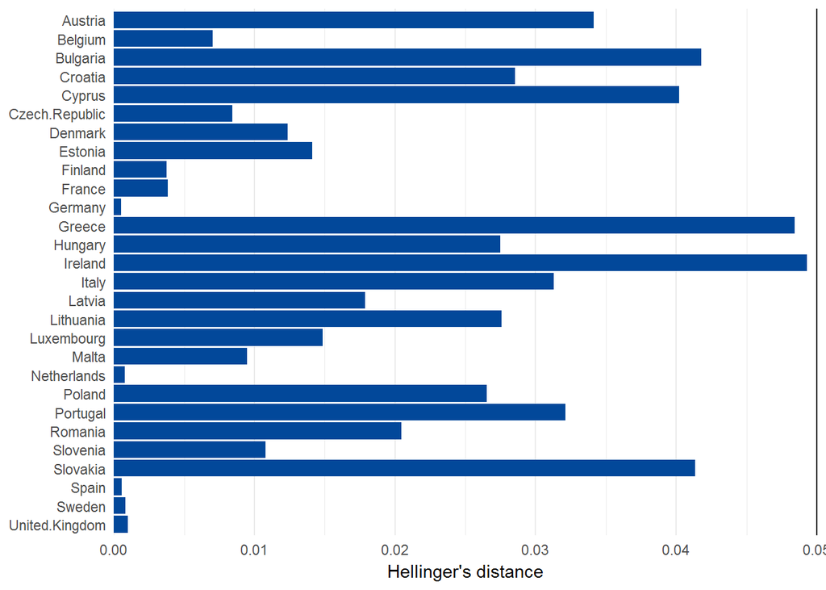

```r
Helld_country(~Y16_HH2a,~y15_Q2a)
```

```r
EQLS$Gender <- EQLS$Y16_HH2a
EWCS$Gender <- EWCS$y15_Q2a
```

### Age

Variables: agenum is the continuous variable, and agecat_5 is that split up in five categories.

**Conclusion: same distribution for EU28, but not in each country**

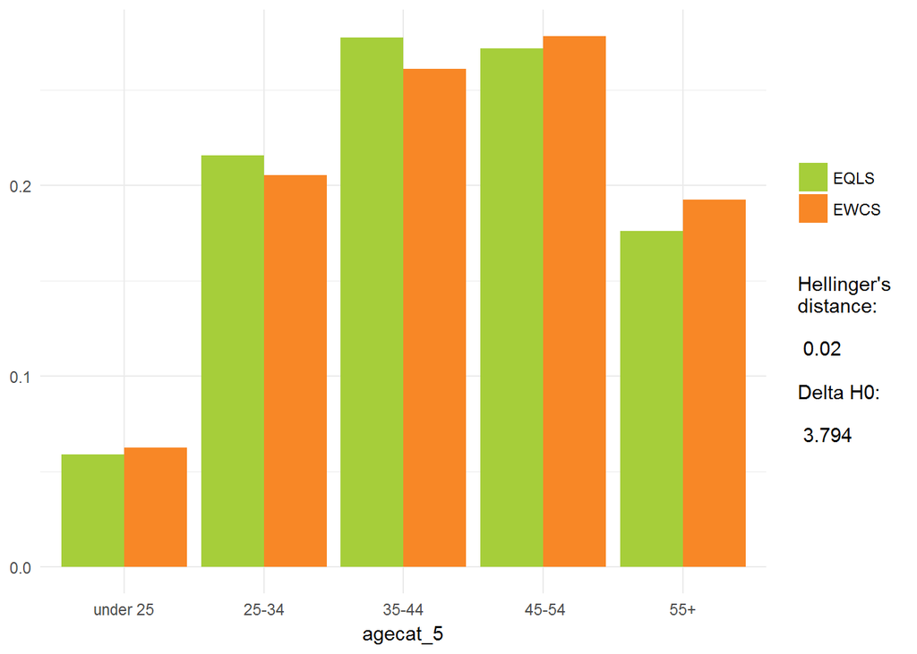

```r
EWCS$agenum <- as.numeric(levels(EWCS$y15_Q2b))[EWCS$y15_Q2b]
EQLS$agenum <- EQLS$Y16_HH2b

EQLS$agecat_5 <- recode(EQLS$Y16_HH2b,"lo:24='under 25';25:34='25-34';35:44='35-44';45:54=' 45-54';55:hi='55+'",as.factor.result=TRUE,
                        levels = c('under 25','25-34','35-44',' 45-54','55+'))

HD(~agecat_5,~agecat_5,name="agecat_5")
```

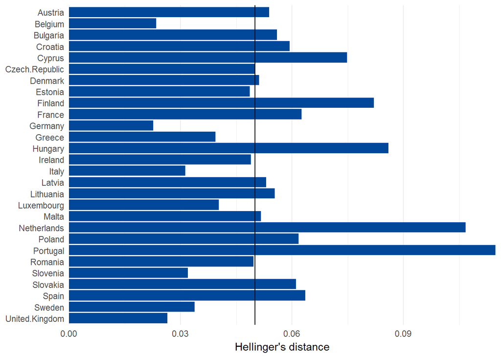

```r
Helld_country(~agecat_5,~agecat_5)
```

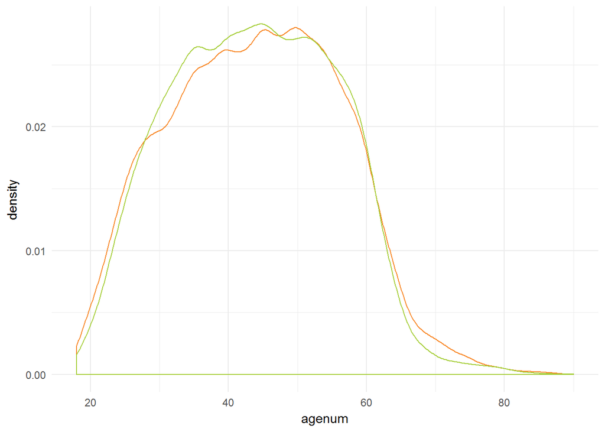

```r
ggplot() +
  geom_density(data=EWCS, aes(x=agenum), colour=EF_orange, na.rm=T) +
  geom_density(data=EQLS, aes(x=agenum), colour=EF_green, na.rm=T) +
  theme_minimal()
```

Note: unweighted

But also looking at the distribution of the continuous variable we can conclude that the distribution is very similar.

### Employment status

variable name: empl_stat

**Conclusion: same distribution for EU28, but not in each country**

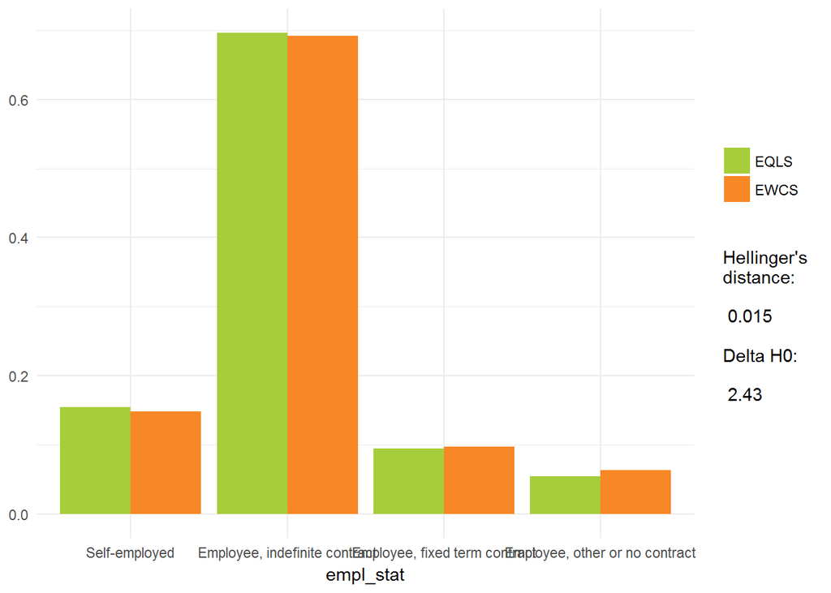

```r
levels(EWCS$y15_Q7) <- trimws(levels(EWCS$y15_Q7), which="both")
EWCS$selfemployed <- EWCS$y15_Q7
EQLS$selfemployed <- EWCS$y15_Q9

EQLS$empl_stat[EQLS$Y16_Q9=="Self-employed"] <- 0
EQLS$empl_stat[EQLS$Y16_Q10=="An unlimited permanent contract"] <- 1
EQLS$empl_stat[EQLS$Y16_Q10=="A fixed term contract of less than 12 months"] <- 2
EQLS$empl_stat[EQLS$Y16_Q10=="A fixed term contract of 12 months or more"] <- 2
EQLS$empl_stat[EQLS$Y16_Q10=="A temporary employment agency contract"] <- 3
EQLS$empl_stat[EQLS$Y16_Q10=="An apprenticeship or other training scheme"] <- 3
EQLS$empl_stat[EQLS$Y16_Q10=="No written contract"] <- 3
EQLS$empl_stat[EQLS$Y16_Q10=="Other"] <- 3

EWCS$empl_stat[EWCS$emp_stat=="self-employed with employees"] <- 0
EWCS$empl_stat[EWCS$emp_stat=="self-employed without employees"] <- 0
EWCS$empl_stat[EWCS$emp_stat=="employee, indefinite contract"] <- 1
EWCS$empl_stat[EWCS$emp_stat=="employee, fixed term contract"] <- 2
EWCS$empl_stat[EWCS$emp_stat=="employee, other or no contract"] <- 3

EQLS$empl_stat <- factor(EQLS$empl_stat,levels=c(0:3),
                         labels=c("Self-employed","Employee, indefinite contract","Employee, fixed term contract","Employee, other or no contract"),
                         ordered=F)
EWCS$empl_stat <- factor(EWCS$empl_stat,levels=c(0:3),
                         labels=c("Self-employed","Employee, indefinite contract","Employee, fixed term contract","Employee, other or no contract"),
                         ordered=F)

HD(~empl_stat,~empl_stat,name="empl_stat")
```

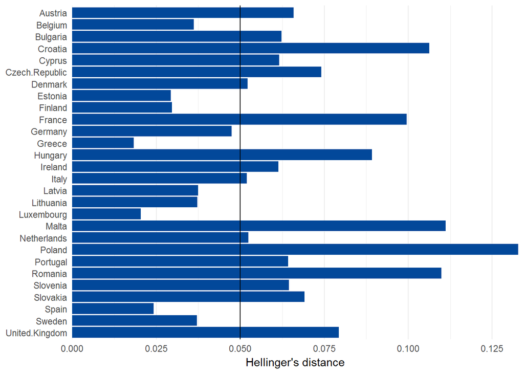

```r
Helld_country(~empl_stat,~empl_stat)
```

Simlified version of employment status

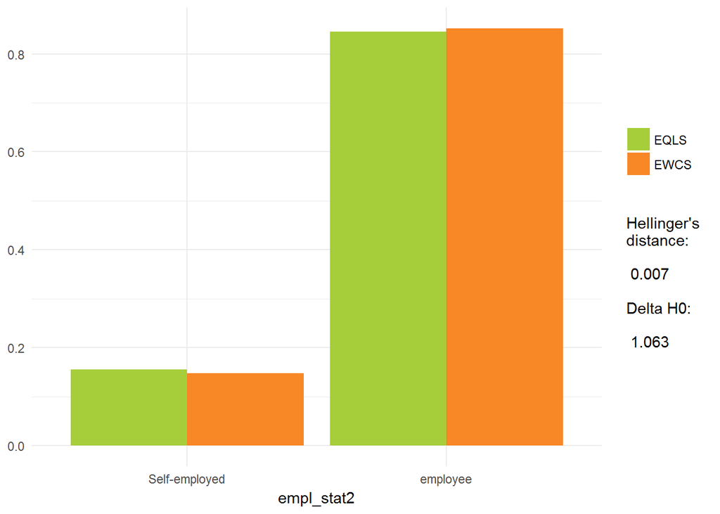

```r
EWCS$empl_stat2[EWCS$empl_stat=="Self-employed"] <- 1
EWCS$empl_stat2[EWCS$empl_stat=="Employee, indefinite contract"] <- 2
EWCS$empl_stat2[EWCS$empl_stat=="Employee, fixed term contract"] <- 2
EWCS$empl_stat2[EWCS$empl_stat=="Employee, other or no contract"] <- 2
EWCS$empl_stat2 <- factor(EWCS$empl_stat2, levels=c(1:2), labels=c("Self-employed","employee"))

EQLS$empl_stat2[EQLS$empl_stat=="Self-employed"] <- 1
EQLS$empl_stat2[EQLS$empl_stat=="Employee, indefinite contract"] <- 2
EQLS$empl_stat2[EQLS$empl_stat=="Employee, fixed term contract"] <- 2
EQLS$empl_stat2[EQLS$empl_stat=="Employee, other or no contract"] <- 2
EQLS$empl_stat2 <- factor(EQLS$empl_stat2, levels=c(1:2), labels=c("Self-employed","employee"))

HD(~empl_stat2,~empl_stat2,name="empl_stat2")
```

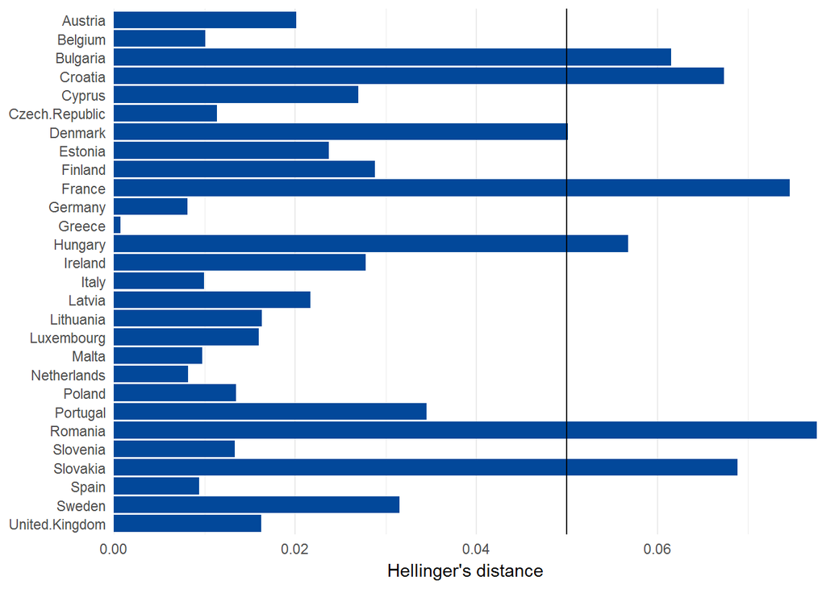

```r
Helld_country(~empl_stat2,~empl_stat2)
```

### Working time

variable name: hours_mainjob totalhour

**Conclusion: distributions are similar but not the same. We could consider rank hot deck for this variable, assuming that the rank, but not the level is the same between the surveys**

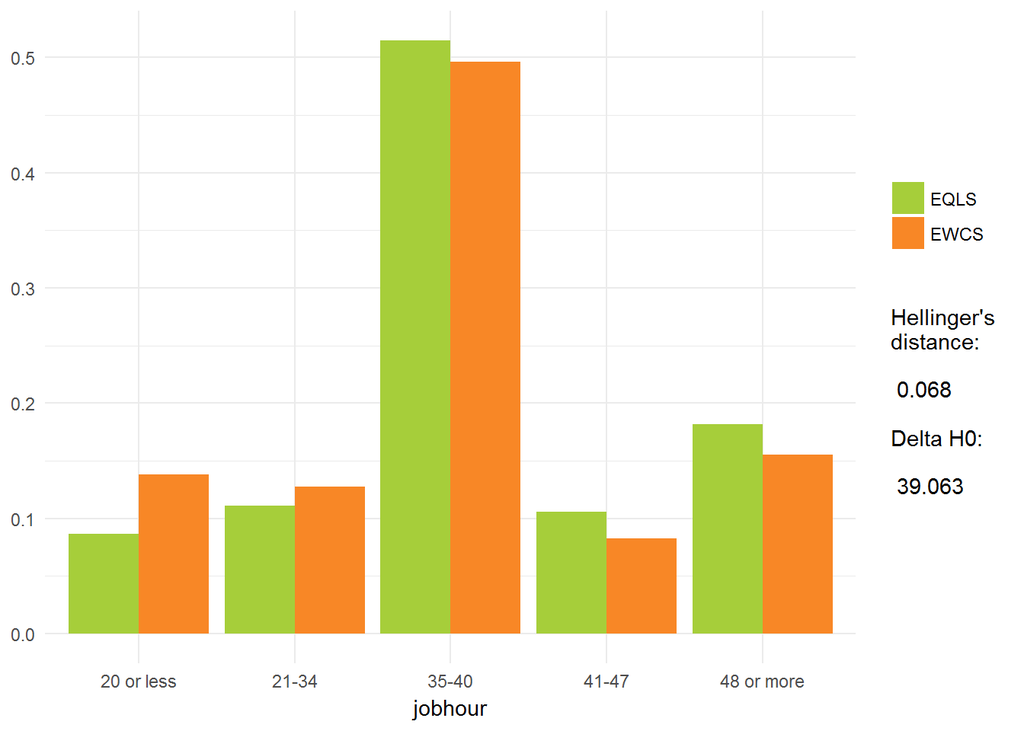

```r
EQLS$hours_mainjob <- as.numeric(levels(EQLS$Y16_Q14))[EQLS$Y16_Q14]
EWCS$hours_mainjob <- as.numeric(levels(EWCS$y15_Q24))[EWCS$y15_Q24]

EQLS$jobhour <- recode(EQLS$hours_mainjob,"lo:20='20 or less';21:34='21-34';35:40='35-40';41:47='41-47';48:hi='48 or more'",as.factor.result=TRUE,
                        levels = c('20 or less','21-34','35-40','41-47','48 or more'))

HD(~jobhour,~jobhour,name="jobhour")
```

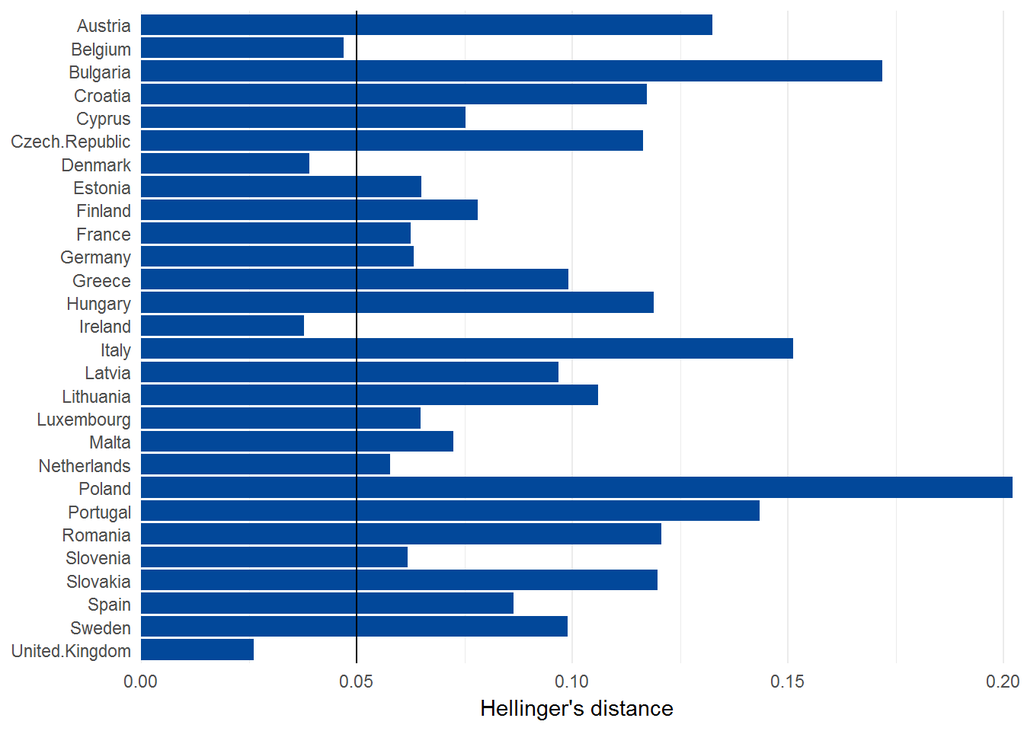

```r
Helld_country(~jobhour,~jobhour)
```

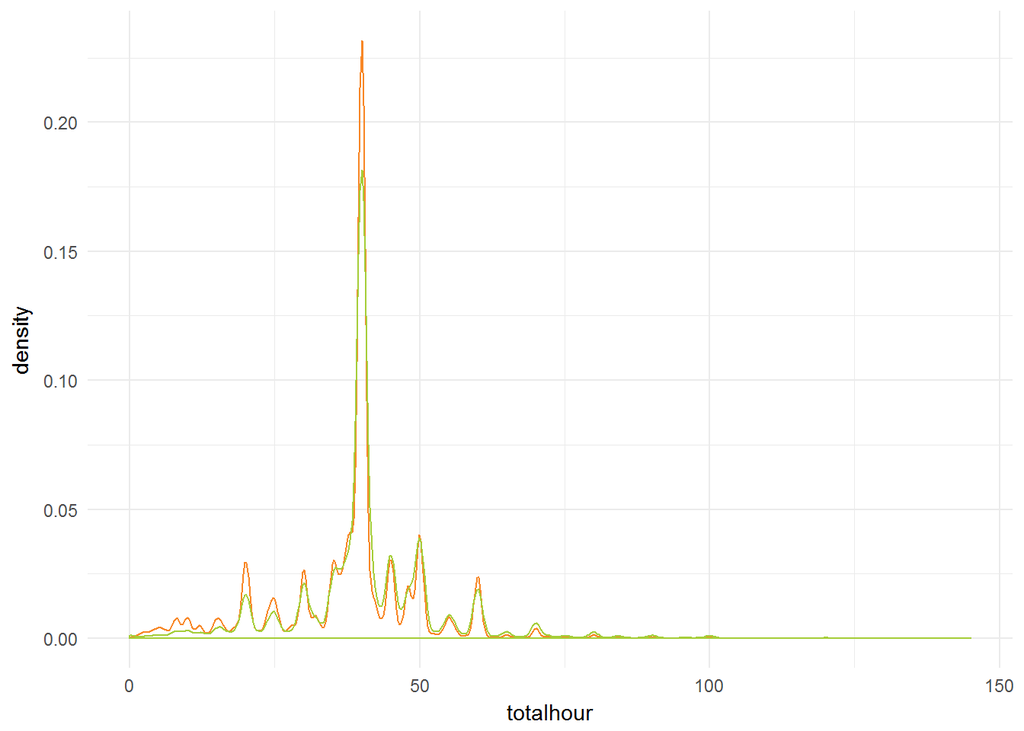

```r
EQLS$hours_secjob <- as.numeric(levels(EQLS$Y16_Q16))[EQLS$Y16_Q16]
EQLS$hours_secjob[is.na(EQLS$Y16_Q16)] <- 0
EQLS$totalhour <- EQLS$hours_secjob + as.numeric(levels(EQLS$Y16_Q14))[EQLS$Y16_Q14]

ggplot() +
  geom_density(data=EWCS, aes(x=totalhour), colour=EF_orange, na.rm=T) +
  geom_density(data=EQLS, aes(x=totalhour), colour=EF_green, na.rm=T) +
  theme_minimal()
```

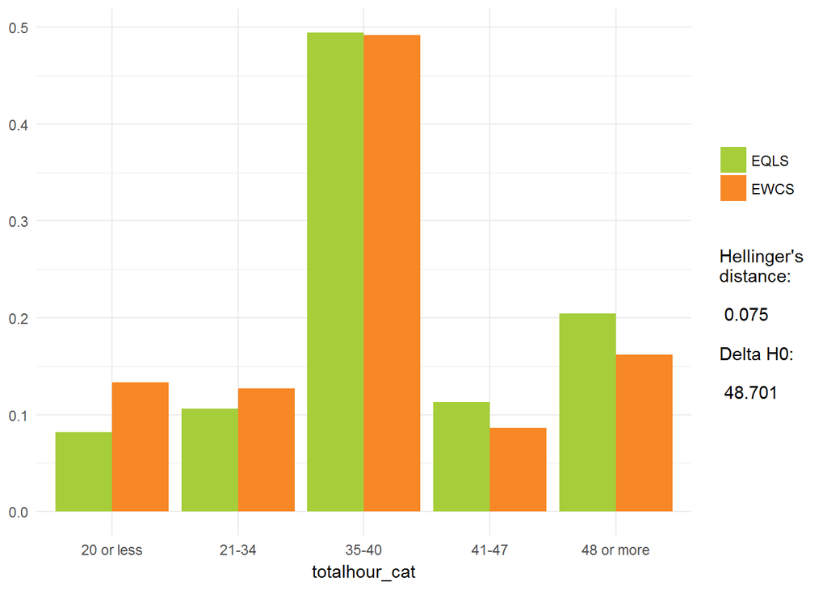

```r
EQLS$totalhour_cat <- recode(EQLS$totalhour,"lo:20='20 or less';21:34='21-34';35:40='35-40';41:47='41-47';48:hi='48 or more'",as.factor.result=TRUE,
                       levels = c('20 or less','21-34','35-40','41-47','48 or more'))

EWCS$totalhour_cat <- recode(EWCS$totalhour,"lo:20='20 or less';21:34='21-34';35:40='35-40';41:47='41-47';48:hi='48 or more'",as.factor.result=TRUE,
                       levels = c('20 or less','21-34','35-40','41-47','48 or more'))

HD(~totalhour_cat,~totalhour_cat,name="totalhour_cat")
```

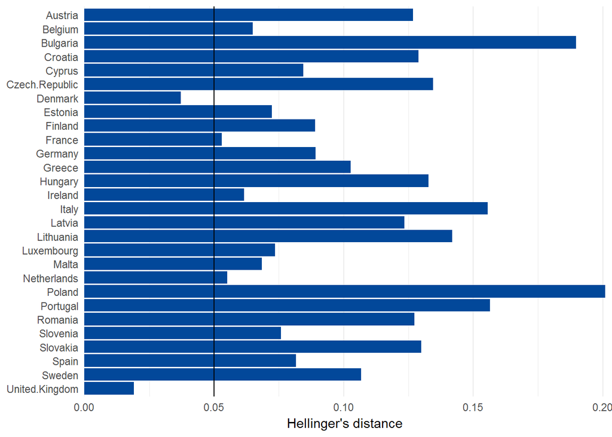

```r
Helld_country(~totalhour_cat,~totalhour_cat)
```

Jobhour is Q24 in EWCS (How many hours do you usually work per week in your main paid job?) and Q14 in EQLS (How many hours do you normally work per week in your main job, including any paid or unpaid overtime?)

The difference in the distributon might be the result of the explicit mentioning of paid or unpaid overtime in the EQLS. Mean of working hours in the EQLS is also 1.5 hours higher than in the EWCS.

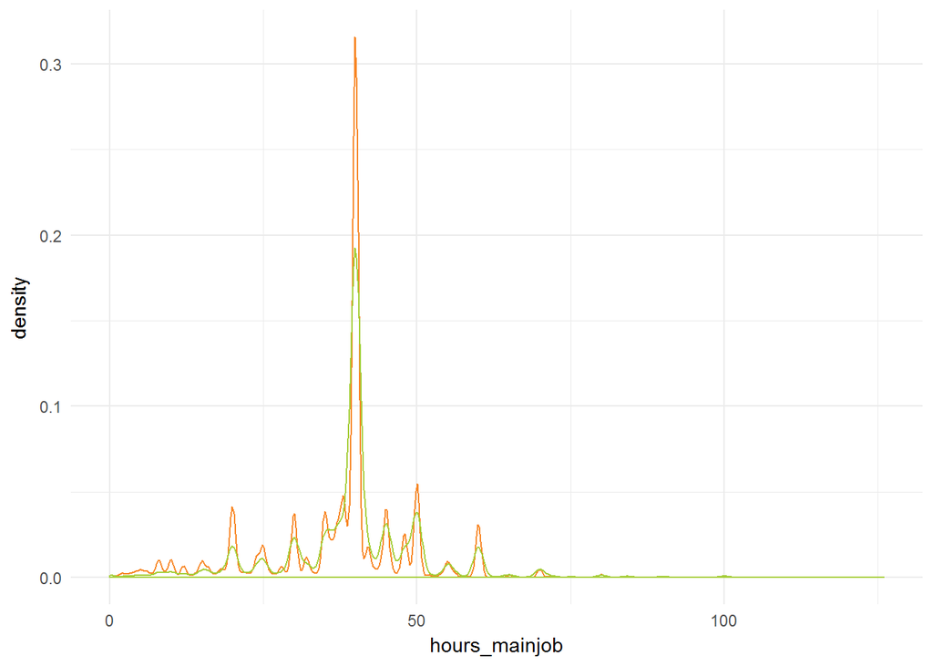

```r
ggplot() +
  geom_density(data=EWCS, aes(x=hours_mainjob), colour=EF_orange, na.rm=T) +
  geom_density(data=EQLS, aes(x=hours_mainjob), colour=EF_green, na.rm=T) +
  theme_minimal()
```

Distribution of continuous variable shows similar pattern.

### Preferred hours

variable: hours_pref (continuous) hours_pref_cat (categorical)

**Conclusion: for the purposes of statistical matching also here we could consider rank hot deck. Proceed with caution.**

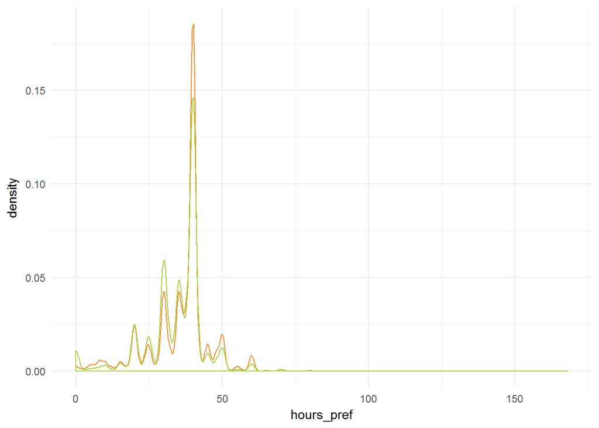

```r
EQLS$Q17 <- as.numeric(levels(EQLS$Y16_Q17))[EQLS$Y16_Q17]
EWCS$hours_pref  <- droplevels(EWCS$y15_Q25)
EWCS$y15_Q25 <- as.numeric(levels(EWCS$hours_pref ))[EWCS$hours_pref]

EQLS$hours_pref <- EQLS$Q17
EWCS$hours_pref <- EWCS$y15_Q25

ggplot() +
  geom_density(data=EWCS, aes(x=hours_pref), colour=EF_orange, na.rm=T) +
  geom_density(data=EQLS, aes(x=hours_pref), colour=EF_green, na.rm=T) +
  theme_minimal()
```

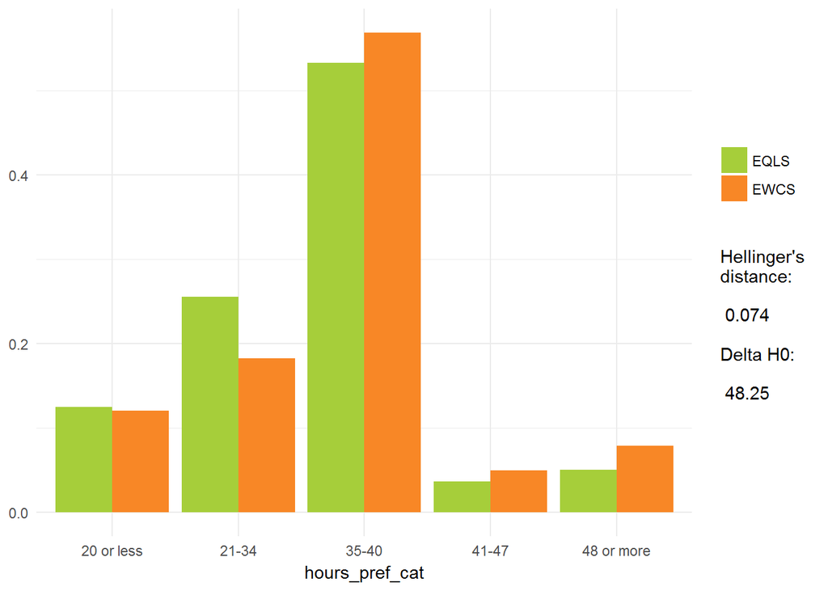

```r
EQLS$hours_pref_cat <- recode(EQLS$hours_pref,"lo:20='20 or less';21:34='21-34';35:40='35-40';41:47='41-47';48:hi='48 or more'",as.factor.result=TRUE,
                       levels = c('20 or less','21-34','35-40','41-47','48 or more'))
EWCS$hours_pref_cat <- recode(EWCS$hours_pref,"lo:20='20 or less';21:34='21-34';35:40='35-40';41:47='41-47';48:hi='48 or more'",as.factor.result=TRUE,
                       levels = c('20 or less','21-34','35-40','41-47','48 or more'))

HD(~hours_pref_cat,~hours_pref_cat,name="hours_pref_cat")
```

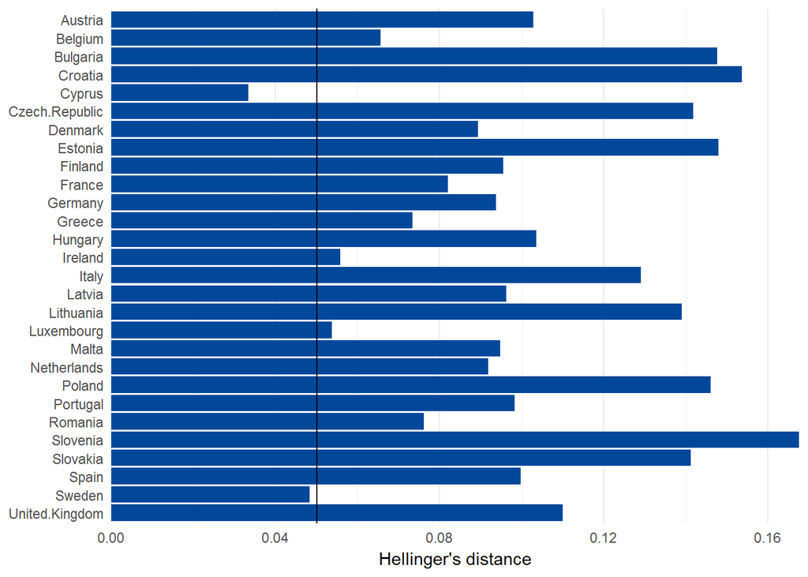

```r
Helld_country(~hours_pref_cat,~hours_pref_cat)
```

EQLS respondents prefer to work fewer hours than EWCS respondents. Possible explanations:

- selection: the EQLS has respondents that work more hours so therefore it is more likely they will want to reduce their hours further
- non-response bias: those respondents that do the EQLS may be triggered by the topic of quality of life, while those respondents that do the EWCS might be more triggered by the topic of work and therefore are more likely to be people that would like to work more.
- EQLS question on preferred working hours asks for ‘the number of your working hours’ and it is not clear if this is interpreted as including or excluding overtime. It is not explicitly mentioned so it is not completely consistent. This may explain their tendency to prefer a lower number of hours.

### Preferred hours: more, the same or less.

variable: prefhour

**Conclusion: not similar**

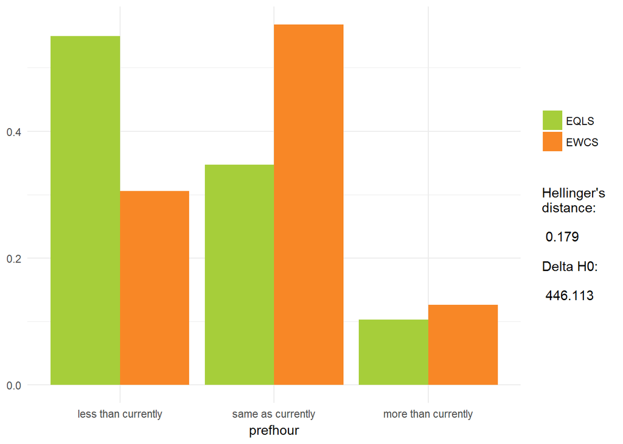

```r
EQLS$prefhour[EQLS$Q17<EQLS$totalhour] <- 0
EQLS$prefhour[EQLS$Q17==EQLS$totalhour] <- 1
EQLS$prefhour[EQLS$Q17>EQLS$totalhour] <- 2

EQLS$prefhour <- factor(EQLS$prefhour,levels=c(0,1,2),labels=c("less than currently","same as currently","more than currently"),ordered=F)

HD(~prefhour,~prefhour,name="prefhour")
```

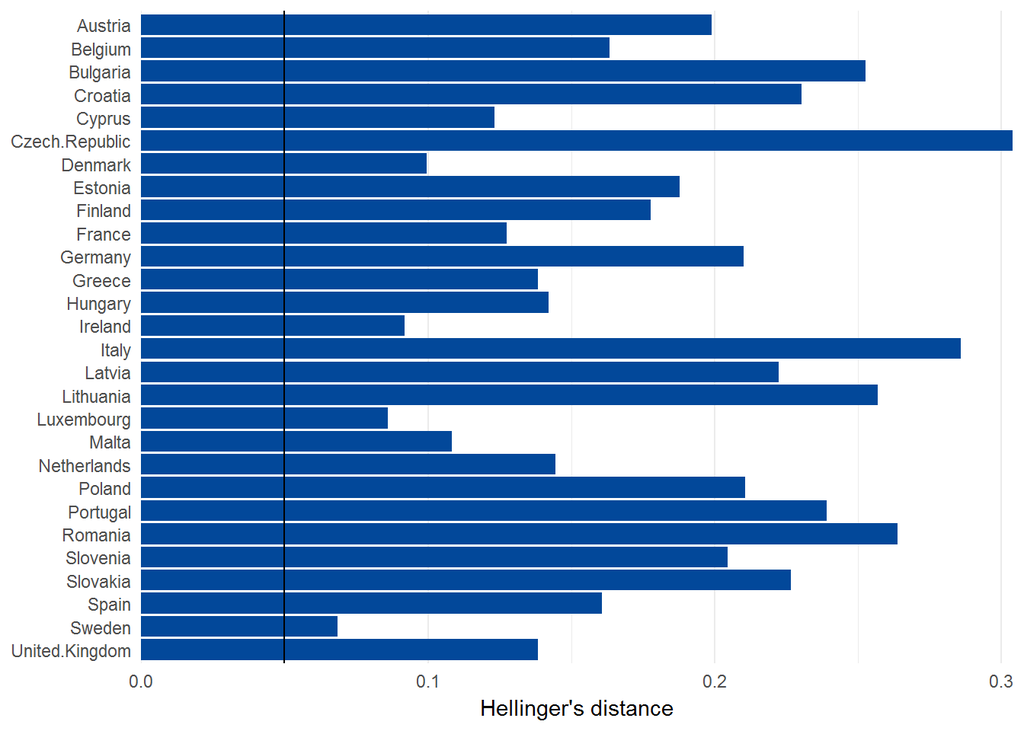

```r
Helld_country(~prefhour,~prefhour)
```

Strong differences between the EWCS and EQLS: this is the result of the combination of findings mentioned above

### ISCO1

Variable: ISCO

**Conclusion: similar distribution. Hellingers distance is on the large side, but the number of categories is also large.**

Following level 1 of the [ISCO 08 classification](http://www.ilo.org/public/english/bureau/stat/isco/docs/structure08.docx) and added the distinction between service and sales workers because that is also done in the EQLS.

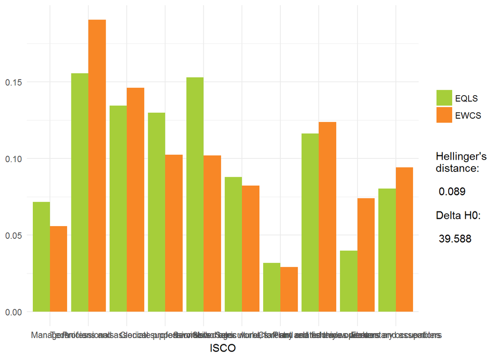

```r
EQLS$ISCO[EQLS$Y16_Q11=="Armed forces occupation"] <- 10
EQLS$ISCO[EQLS$Y16_Q11=="Manager"] <- 1
EQLS$ISCO[EQLS$Y16_Q11=="Professional"] <- 2
EQLS$ISCO[EQLS$Y16_Q11=="Technician or junior professional"] <- 3
EQLS$ISCO[EQLS$Y16_Q11=="Clerical support worker"] <- 4
EQLS$ISCO[EQLS$Y16_Q11=="Service worker"] <- 5
EQLS$ISCO[EQLS$Y16_Q11=="Sales worker"] <- 6
EQLS$ISCO[EQLS$Y16_Q11=="Skilled agricultural forestry and fishery worker"] <- 7
EQLS$ISCO[EQLS$Y16_Q11=="Craft and related trades worker"] <- 8
EQLS$ISCO[EQLS$Y16_Q11=="Plant and machine operator or assembler"] <- 9
EQLS$ISCO[EQLS$Y16_Q11=="Elementary occupations" ] <- 10

EWCS$ISCO[EWCS$y15_isco_08_1=="Armed forces occupations"] <- 10
EWCS$ISCO[EWCS$y15_isco_08_1=="Managers"] <- 1
EWCS$ISCO[EWCS$y15_isco_08_1=="Professionals"] <- 2
EWCS$ISCO[EWCS$y15_isco_08_1=="Technicians and associate professionals"] <- 3
EWCS$ISCO[EWCS$y15_isco_08_1=="Clerical support workers"] <- 4
EWCS$ISCO[EWCS$y15_isco_08_2=="Personal service workers" | EWCS$y15_isco_08_2=="Personal care workers" | EWCS$y15_isco_08_2=="Protective services workers"] <- 5
EWCS$ISCO[EWCS$y15_isco_08_2=="Sales workers"] <- 6
EWCS$ISCO[EWCS$y15_isco_08_1=="Skilled agricultural, forestry and fishery workers"] <- 7
EWCS$ISCO[EWCS$y15_isco_08_1=="Craft and related trades workers"] <- 8
EWCS$ISCO[EWCS$y15_isco_08_1=="Plant and machine operators, and assemblers"] <- 9
EWCS$ISCO[EWCS$y15_isco_08_1=="Elementary occupations"] <- 10

EQLS$ISCO <- factor(EQLS$ISCO,
                    levels=c(1:10),
                    labels=c("Managers",
                             "Professionals",
                             "Technicians and associate professionals",
                             "Clerical support workers",
                             "Service workers",
                             "Sales workers",
                             "Skilled agricultural, forestry and fishery workers",
                             "Craft and related trades workers",
                             "Plant and machine operators and assemblers",
                             "Elementary occupations"),
                    ordered=F)

EWCS$ISCO <- factor(EWCS$ISCO,
                    levels=c(1:10),
                    labels=c("Managers",
                             "Professionals",
                             "Technicians and associate professionals",
                             "Clerical support workers",
                             "Service workers",
                             "Sales workers",
                             "Skilled agricultural, forestry and fishery workers",
                             "Craft and related trades workers",
                             "Plant and machine operators and assemblers",
                             "Elementary occupations"),
                    ordered=F)

HD(~ISCO,~ISCO,name="ISCO")
```

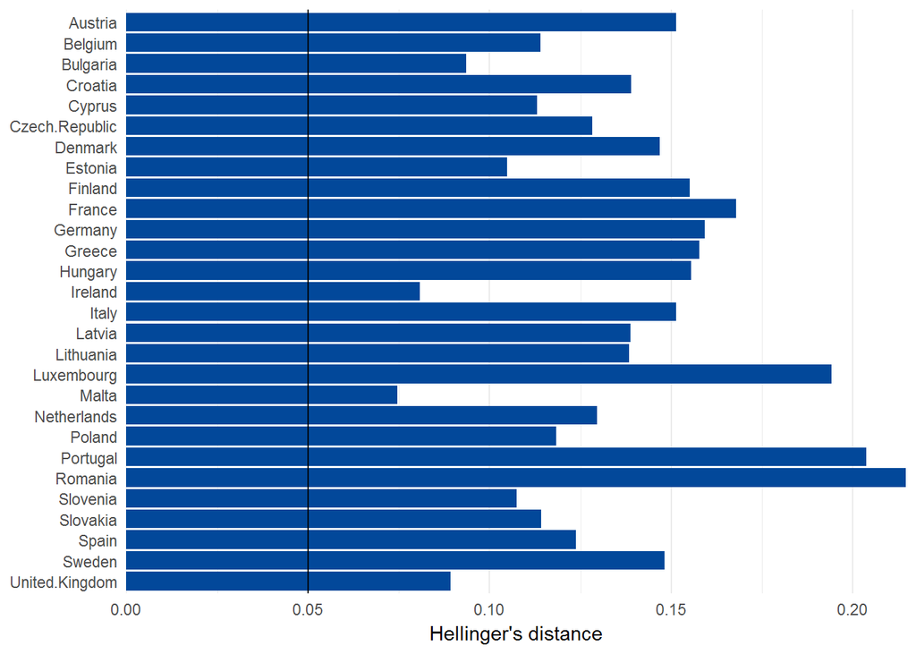

```r
Helld_country(~ISCO,~ISCO)
```

Similarity in distribution is overall not bad given the amount of categories, but EQLS seems to have more service workers and EWCS more professionals.

Simplified version of ISCO

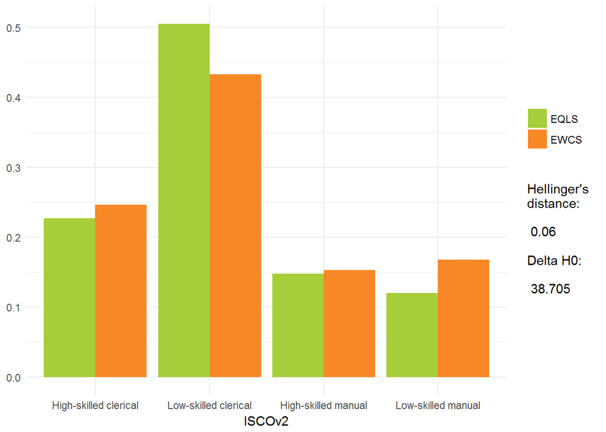

```r
EWCS$ISCOv2[EWCS$ISCO=="Managers"] <- 1
EWCS$ISCOv2[EWCS$ISCO=="Professionals"] <- 1
EWCS$ISCOv2[EWCS$ISCO=="Technicians and associate professionals" ] <- 2
EWCS$ISCOv2[EWCS$ISCO=="Clerical support workers" ] <- 2
EWCS$ISCOv2[EWCS$ISCO=="Service workers" ] <- 2
EWCS$ISCOv2[EWCS$ISCO=="Sales workers" ] <- 2
EWCS$ISCOv2[EWCS$ISCO=="Skilled agricultural, forestry and fishery workers" ] <- 3
EWCS$ISCOv2[EWCS$ISCO=="Craft and related trades workers"] <- 3
EWCS$ISCOv2[EWCS$ISCO=="Plant and machine operators and assemblers"] <- 4
EWCS$ISCOv2[EWCS$ISCO=="Elementary occupations"] <- 4
EWCS$ISCOv2[EWCS$y15_isco_08_1=="Armed forces occupations"] <- 4
EWCS$ISCOv2 <- factor(EWCS$ISCOv2, levels=c(1:4), labels=c("High-skilled clerical","Low-skilled clerical","High-skilled manual","Low-skilled manual"))

EQLS$ISCOv2[EQLS$ISCO=="Managers"] <- 1
EQLS$ISCOv2[EQLS$ISCO=="Professionals"] <- 1
EQLS$ISCOv2[EQLS$ISCO=="Technicians and associate professionals" ] <- 2
EQLS$ISCOv2[EQLS$ISCO=="Clerical support workers" ] <- 2
EQLS$ISCOv2[EQLS$ISCO=="Service workers" ] <- 2
EQLS$ISCOv2[EQLS$ISCO=="Sales workers" ] <- 2
EQLS$ISCOv2[EQLS$ISCO=="Skilled agricultural, forestry and fishery workers" ] <- 3
EQLS$ISCOv2[EQLS$ISCO=="Craft and related trades workers"] <- 3
EQLS$ISCOv2[EQLS$ISCO=="Plant and machine operators and assemblers"] <- 4
EQLS$ISCOv2[EQLS$ISCO=="Elementary occupations"] <- 4
EQLS$ISCOv2[EQLS$Y16_Q11=="Armed forces occupation"] <- 4
EQLS$ISCOv2 <- factor(EQLS$ISCOv2, levels=c(1:4), labels=c("High-skilled clerical","Low-skilled clerical","High-skilled manual","Low-skilled manual"))

HD(~ISCOv2,~ISCOv2,name="ISCOv2")
```

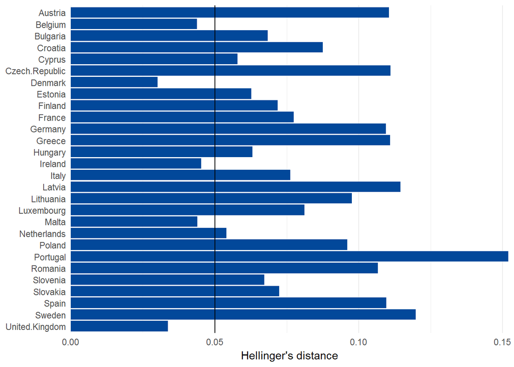

```r
Helld_country(~ISCOv2,~ISCOv2)
```

### Partner

Variable: partner

**Conclusion: same distribution for EU28, but differences at country level**

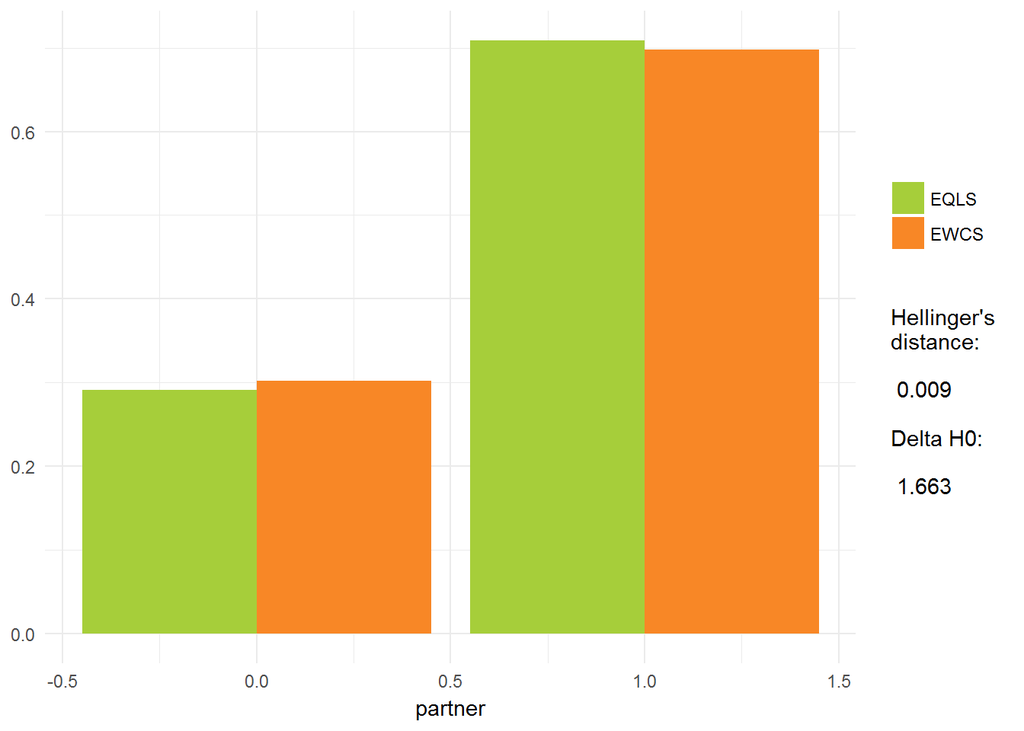

```r
EQLS$partner <- EQLS$haspartner

HD(~partner,~partner,name="partner")
```

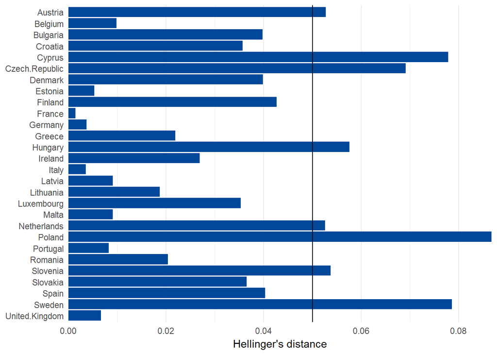

```r
Helld_country(~partner,~partner)
```

### Children

variable: num_children

**Conclusion: the same distribution**

Note: havent plotted it by country, because this is difficult to program. Thats because the max number of children is not the same in each country.

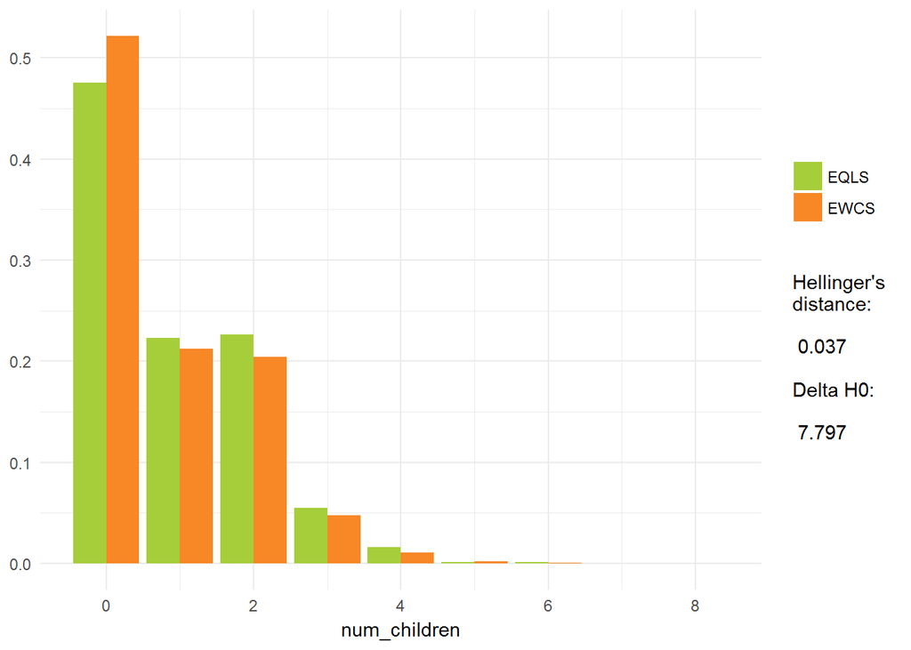

```r
EWCS$num_children <- apply(EWCS[,c("y15_Q3c_2","y15_Q3c_3","y15_Q3c_4","y15_Q3c_5","y15_Q3c_6","y15_Q3c_7","y15_Q3c_8","y15_Q3c_9","y15_Q3c_10")],
                        1,
                        function(x) length(which(x=="Child: Son/daughter of respondent or cohabiting partner" |
                                                 x=="Daughter or son-in-law                                 " |
                                                 x=="Grand child                                            " )
                                           )
                        )

EQLS$num_children <- apply(EQLS[,c("Y16_HH3c_2","Y16_HH3c_3","Y16_HH3c_4","Y16_HH3c_5","Y16_HH3c_6","Y16_HH3c_7","Y16_HH3c_8","Y16_HH3c_9","Y16_HH3c_10")],
                        1,
                        function(x) length(which(x=="Your son/daughter" |
                                                 x=="Your stepchild (only separated in 4th EQLS)" |
                                                 x=="Your daughter-in-law or son-in-law" |
                                                 x=="Your grandchild")
                                           )
                        )


HD(~num_children,~num_children,name="num_children")
```

Simplified version of having children

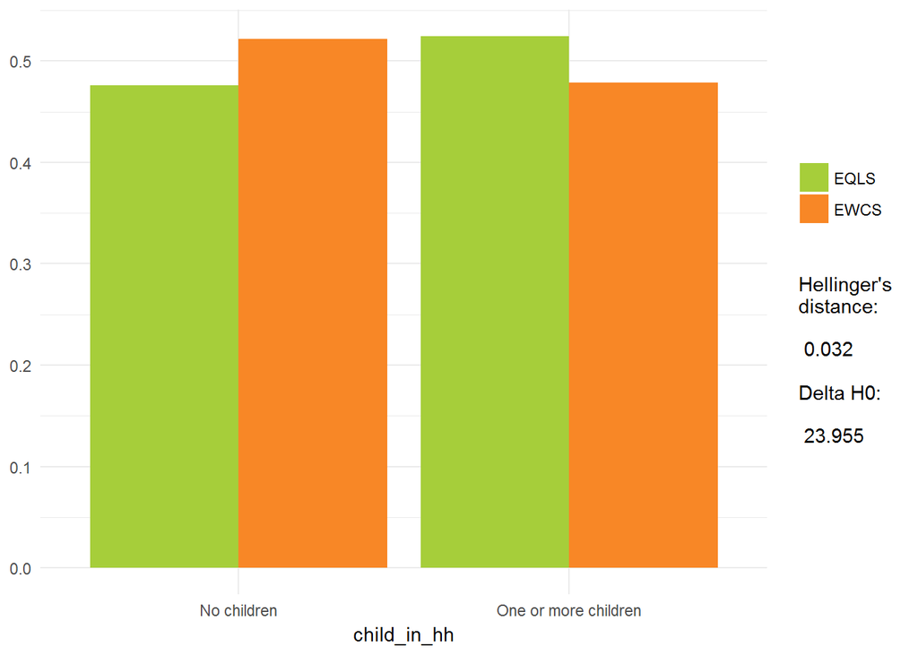

```r
EWCS$child_in_hh[EWCS$num_children>0]  <- 1
EWCS$child_in_hh[EWCS$num_children==0] <- 0

EQLS$child_in_hh[EQLS$num_children>0]  <- 1
EQLS$child_in_hh[EQLS$num_children==0] <- 0

EWCS$child_in_hh <- factor(EWCS$child_in_hh, levels = c(0,1), labels = c("No children", "One or more children"))
EQLS$child_in_hh <- factor(EQLS$child_in_hh, levels = c(0,1), labels = c("No children", "One or more children"))

HD(~child_in_hh,~child_in_hh,name = "child_in_hh")
```

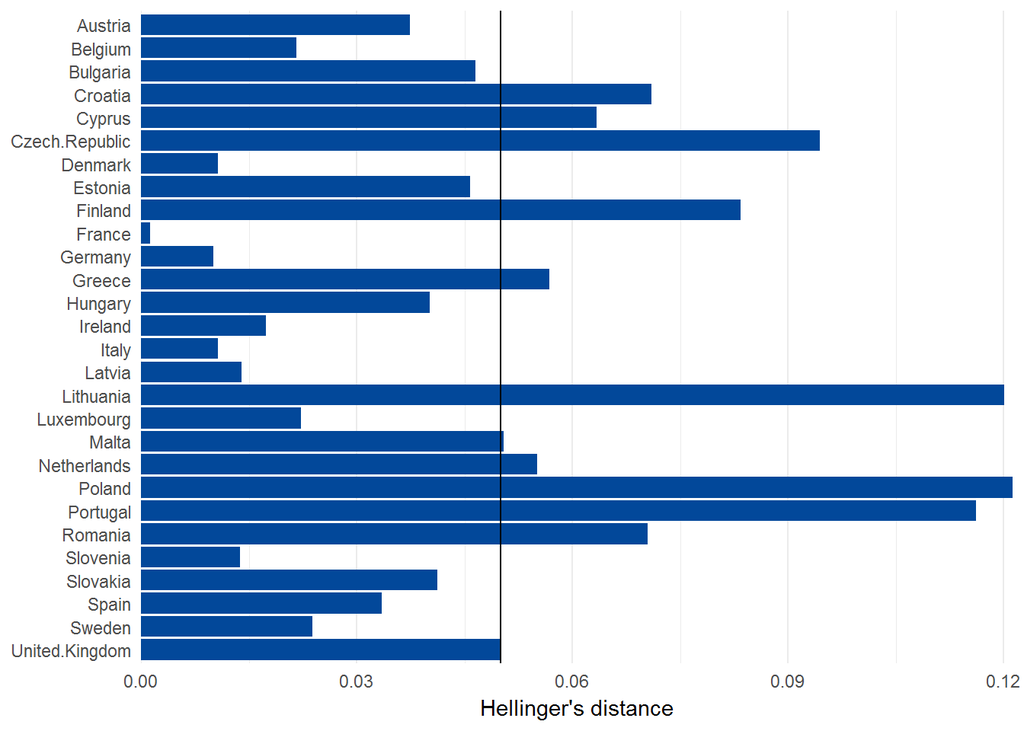

```r
Helld_country(~child_in_hh,~child_in_hh)
```

### Partner / Child interaction

Variable: partner_child

**Conclusion: also the joint distributions of partner and children are very similar on EU28 level. Less so on country level**

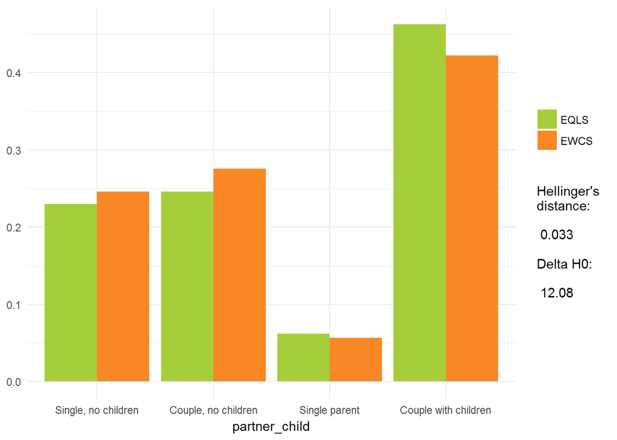

```r
EQLS$partner_child[EQLS$partner==0 & EQLS$num_children==0] <- 0
EQLS$partner_child[EQLS$partner==1 & EQLS$num_children==0] <- 1
EQLS$partner_child[EQLS$partner==0 & EQLS$num_children> 0] <- 2
EQLS$partner_child[EQLS$partner==1 & EQLS$num_children> 0] <- 3

EWCS$partner_child[EWCS$partner==0 & EWCS$num_children==0] <- 0
EWCS$partner_child[EWCS$partner==1 & EWCS$num_children==0] <- 1
EWCS$partner_child[EWCS$partner==0 & EWCS$num_children> 0] <- 2
EWCS$partner_child[EWCS$partner==1 & EWCS$num_children> 0] <- 3

EQLS$partner_child <- factor(EQLS$partner_child,levels=c(0:3),labels=c("Single, no children","Couple, no children","Single parent","Couple with children"),ordered=F)
EWCS$partner_child <- factor(EWCS$partner_child,levels=c(0:3),labels=c("Single, no children","Couple, no children","Single parent","Couple with children"),ordered=F)

HD(~partner_child,~partner_child,name = "partner_child")
```

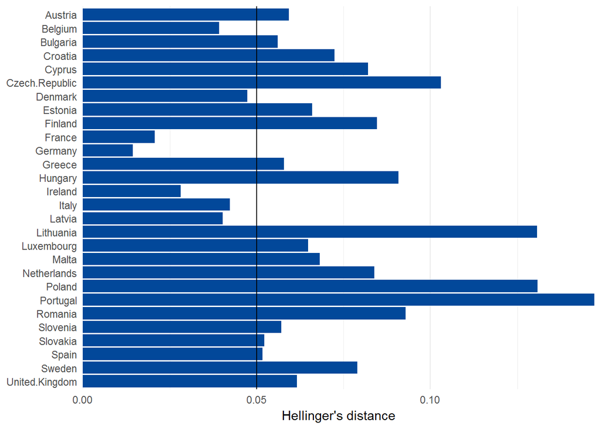

```r
Helld_country(~partner_child,~partner_child)
```